# 04. Whole-Transcriptome Relative-Rate Tests for SIM

# 3 3. Run Relative Rate Tests

Each comparison is tested once with the pre-specified two-sided alternative. Direction is described from the sign of the Z-score, and Holm-adjusted p-values are reported at the 0.01 threshold.

```r
# RelaRate.test() was checked in the installed TreeExp 0.99.3 package: it supports
# a single two-sided alternative and has Pi = 0 as its default variance parameter.
# A two-sided call avoids selecting a direction after running two one-sided tests.
run_relarate_set <- function(
  expression_table,
  pairs,
  alternative = "two.sided",
  warning_tracker = NULL,
  replicate_id = NULL
) {
  results <- vector("list", nrow(pairs))

  for (i in seq_len(nrow(pairs))) {
    test_result <- withCallingHandlers(
      RelaRate.test(
        expTable = expression_table,
        x = pairs$species1[i],
        y = pairs$species2[i],
        outgroup = outgroup_taxon,
        alternative = alternative
      ),
      warning = function(w) {
        if (grepl("NaNs produced", conditionMessage(w), fixed = TRUE)) {
          if (!is.null(warning_tracker) && !is.null(replicate_id)) {
            warning_tracker$undefined_z[replicate_id, pairs$species2[i]] <- TRUE
          }
          tryInvokeRestart("muffleWarning")
        }
      }
    )

    results[[i]] <- data.frame(
      tissue = tissue, species1 = pairs$species1[i], species2 = pairs$species2[i],
      outgroup = outgroup_taxon, zscore = as.numeric(test_result[[1]]),
      hypothesis = as.character(test_result[[2]]), p_value = as.numeric(test_result[[3]])
    )
  }

  out <- do.call(rbind, results)
  out$direction <- ifelse(
    is.finite(out$zscore) & out$zscore > 0, "SIM faster",
    ifelse(is.finite(out$zscore) & out$zscore < 0, "Comparator faster", "Undefined")
  )
  out$padj_holm <- p.adjust(out$p_value, method = "holm")
  out$p_value_numeric <- out$p_value
  out$p_value <- format(out$p_value, scientific = TRUE, trim = TRUE)
  out
}

tot_LA <- run_relarate_set(exp_table, comparison_table, alternative = "two.sided")
tot_LA <- tot_LA[order(tot_LA$species2), ]
# Retain the raw full-transcriptome SIM-to-SUZ and MEL-to-SUZ distances for cross-scale visualisation.
full_distance_matrix <- TreeExp::dist.sou(exp_table)
sim_distance_col <- if ("SIM_LA" %in% rownames(full_distance_matrix)) "SIM_LA" else "SIM"
mel_distance_col <- if ("MEL_LA" %in% rownames(full_distance_matrix)) "MEL_LA" else "MEL"
suz_distance_col <- if ("SUZ_LA" %in% rownames(full_distance_matrix)) "SUZ_LA" else "SUZ"
tot_LA$SIM_to_SUZ_distance <- as.numeric(full_distance_matrix[suz_distance_col, sim_distance_col])
tot_LA$MEL_to_SUZ_distance <- as.numeric(full_distance_matrix[suz_distance_col, mel_distance_col])

write.table(tot_LA, file = "treeexp_LA_SIM_relative_rate_results.txt", quote = FALSE, col.names = TRUE, row.names = FALSE, sep = "\t")
tot_LA
```

```
##   tissue species1 species2 outgroup    zscore hypothesis       p_value
## 4     LA      SIM      ERE      SUZ  9.614081  two.sided  6.972911e-22
## 2     LA      SIM      MEL      SUZ 19.363394  two.sided  1.571815e-83
## 3     LA      SIM      SAN      SUZ 11.005154  two.sided  3.608971e-28
## 1     LA      SIM      SEC      SUZ 25.317935  two.sided 2.027325e-141
##    direction     padj_holm p_value_numeric SIM_to_SUZ_distance
## 4 SIM faster  6.972911e-22    6.972911e-22           0.1450257
## 2 SIM faster  4.715445e-83    1.571815e-83           0.1450257
## 3 SIM faster  7.217942e-28    3.608971e-28           0.1450257
## 1 SIM faster 8.109299e-141   2.027325e-141           0.1450257
##   MEL_to_SUZ_distance
## 4           0.1144751
## 2           0.1144751
## 3           0.1144751
## 1           0.1144751
```

# 4 4. Plot Full-Data SIM vs All species Relative Rate Test

This plot shows the SIM-vs-species z-score from the full filtered LA gene set.

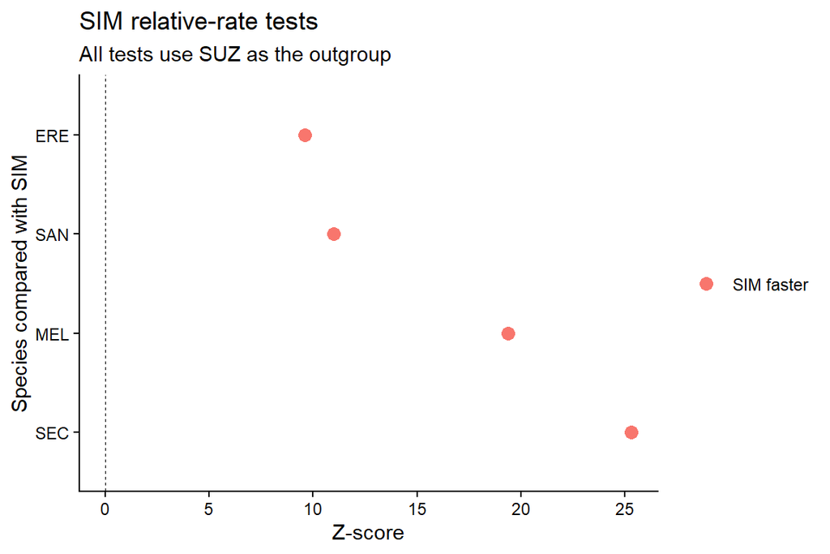

Full-data SIM relative-rate Z-scores versus each comparator.

```r
species_order <- comparison_taxa
tot_LA$species2 <- factor(tot_LA$species2, levels = species_order)

p_full_tests <- ggplot(tot_LA, aes(x = species2, y = zscore, color = direction)) +
  geom_hline(yintercept = 0, linetype = "dashed", linewidth = 0.3) +
  geom_point(size = 3) +
  coord_flip() +
  theme_classic() +
  labs(title = "SIM relative-rate tests ", subtitle = "All tests use SUZ as the outgroup", x = "Species compared with SIM", y = "Z-score", color = NULL)

p_full_tests
```

```r
ggsave("treeexp_LA_SIM_full_relative_rate_tests.png", p_full_tests, width = 6, height = 4, dpi = 300)
```

# 5 5. Random 500-Gene Relative Rate Tests

This repeats the SIM relative-rate tests 500 times. Each repeat randomly samples 500 genes from the filtered LA gene set without replacement.

```r
# Draw the same 500-gene subsets across all comparisons within each replicate.
if (nrow(exp_table) < genes_per_subset) stop("Not enough genes to sample ", genes_per_subset, " genes without replacement. Available genes: ", nrow(exp_table))
sampled_results <- vector("list", random_repeats)
warning_tracker <- new.env(parent = emptyenv())
warning_tracker$undefined_z <- matrix(FALSE, nrow = random_repeats, ncol = nrow(comparison_table), dimnames = list(NULL, comparison_table$species2))

for (replicate_id in seq_len(random_repeats)) {
  sampled_genes <- sample(rownames(exp_table), size = genes_per_subset, replace = FALSE)
  sampled_exp_table <- exp_table[sampled_genes, , drop = FALSE]
  replicate_results <- run_relarate_set(sampled_exp_table, comparison_table, alternative = "two.sided", warning_tracker = warning_tracker, replicate_id = replicate_id)
  replicate_results$replicate <- replicate_id
  replicate_results$sampled_genes <- genes_per_subset
  sampled_results[[replicate_id]] <- replicate_results
}

sampled_LA <- do.call(rbind, sampled_results)
sampled_LA$species2 <- factor(sampled_LA$species2, levels = species_order)
sampled_LA_finite <- sampled_LA[is.finite(sampled_LA$zscore), ]

for (comparison_species in comparison_table$species2) {
  undefined_count <- sum(warning_tracker$undefined_z[, comparison_species])
  cat(sprintf("SIM vs %s: %d/%d undefined Z-scores (%.1f%%) at n=%d", comparison_species, undefined_count, random_repeats, 100 * undefined_count / random_repeats, genes_per_subset))
}
```

```
## SIM vs SEC: 65/500 undefined Z-scores (13.0%) at n=500SIM vs MEL: 94/500 undefined Z-scores (18.8%) at n=500SIM vs SAN: 0/500 undefined Z-scores (0.0%) at n=500SIM vs ERE: 2/500 undefined Z-scores (0.4%) at n=500
```

```r
write.table(sampled_LA, file = "treeexp_LA_SIM_500_gene_500_repeats.txt", quote = FALSE, col.names = TRUE, row.names = FALSE, sep = "\t")
head(sampled_LA)
```

```
##   tissue species1 species2 outgroup    zscore hypothesis      p_value
## 1     LA      SIM      SEC      SUZ 12.963813  two.sided 1.962436e-38
## 2     LA      SIM      MEL      SUZ       NaN  two.sided          NaN
## 3     LA      SIM      SAN      SUZ  2.635189  two.sided 8.409038e-03
## 4     LA      SIM      ERE      SUZ  4.239745  two.sided 2.237740e-05
## 5     LA      SIM      SEC      SUZ  1.257397  two.sided 2.086099e-01
## 6     LA      SIM      MEL      SUZ  2.087402  two.sided 3.685180e-02
##    direction    padj_holm p_value_numeric replicate sampled_genes
## 1 SIM faster 5.887309e-38    1.962436e-38         1           500
## 2  Undefined          NaN             NaN         1           500
## 3 SIM faster 8.409038e-03    8.409038e-03         1           500
## 4 SIM faster 4.475481e-05    2.237740e-05         1           500
## 5 SIM faster 6.258296e-01    2.086099e-01         2           500
## 6 SIM faster 1.474072e-01    3.685180e-02         2           500
```

# 6 6. All-Species Random Z-Score Distributions

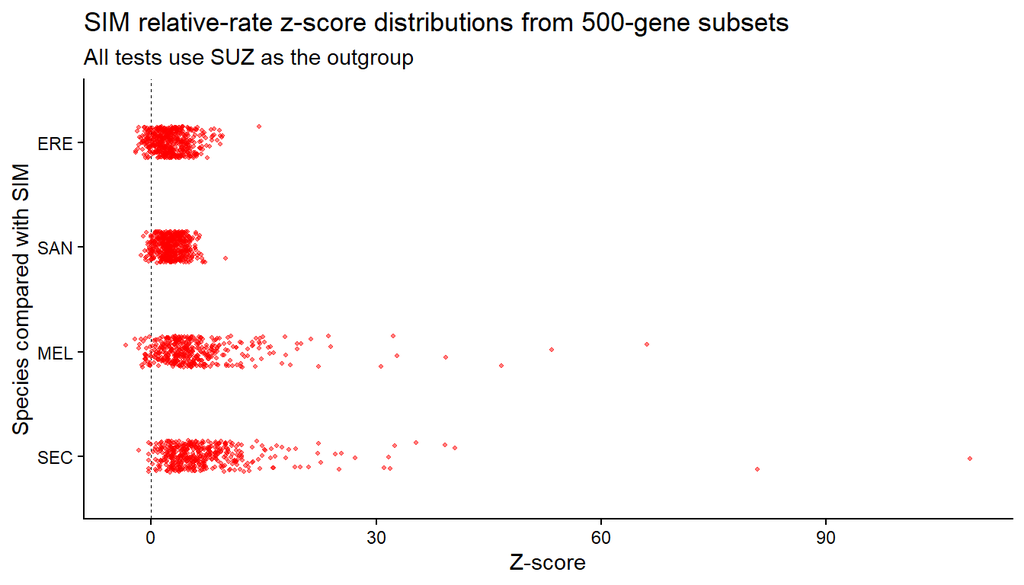

Relative-rate Z-scores from repeated 500-gene subsets.

```r
sampled_LA_finite <- sampled_LA[is.finite(sampled_LA$zscore), ]

p_all_random_zscores <- ggplot(sampled_LA_finite, aes(x = species2, y = zscore)) +
  geom_hline(yintercept = 0, linetype = "dashed", linewidth = 0.3) +
  geom_jitter(color = "red", width = 0.15, height = 0, alpha = 0.5, size = 0.8) +
  coord_flip() +
  theme_classic() +
  labs(title = "SIM relative-rate z-score distributions from 500-gene subsets", subtitle = "All tests use SUZ as the outgroup", x = "Species compared with SIM", y = "Z-score")
p_all_random_zscores
```

```r
ggsave("treeexp_LA_SIM_all_random_zscores.png", p_all_random_zscores, width = 7, height = 4, dpi = 300)
```

# 7 7. SIM-vs-MEL Random Z-Score Distribution

This plot shows the SIM-vs-MEL z-score distribution across the 500 random 500-gene subsets.

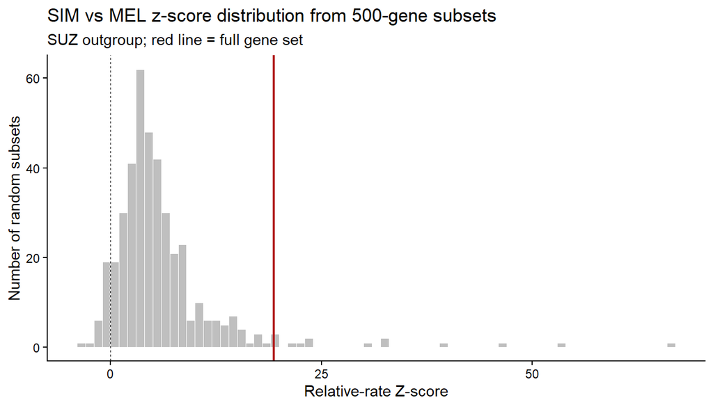

SIM-versus-MEL subset Z-score distribution.

```r
sampled_LA_finite <- sampled_LA[is.finite(sampled_LA$zscore), ]
sampled_LA_mel <- subset(sampled_LA_finite, as.character(species2) == mel_taxon)
sim_mel_full <- subset(tot_LA, as.character(species2) == mel_taxon)
p_mel_random_zscores <- ggplot(sampled_LA_mel, aes(x = zscore)) +
  geom_histogram(binwidth = 1, boundary = 0, fill = "grey75", color = "white", linewidth = 0.2) +
  geom_vline(xintercept = 0, linetype = "dashed", linewidth = 0.3) +
  geom_vline(data = sim_mel_full, aes(xintercept = zscore), color = "firebrick", linewidth = 0.8) +
  theme_classic() +
  labs(title = "SIM vs MEL z-score distribution from 500-gene subsets", subtitle = "SUZ outgroup; red line = full gene set", x = "Relative-rate Z-score", y = "Number of random subsets")
p_mel_random_zscores
```

```r
ggsave("treeexp_LA_SIM_vs_MEL_random_500_gene_zscore_distribution.png", p_mel_random_zscores, width = 7, height = 4, dpi = 300)
```

# 8. Subset Stability Summary

This section reports descriptive stability summaries for the shared random subsets; it is not a confirmatory statistical test.

```r
# This is a sensitivity/stability analysis, not an independent statistical test: all
# subsets are resampled from the same full filtered transcriptome.
subset_summary <- do.call(rbind, lapply(split(sampled_LA, sampled_LA$species2), function(df) {
  finite_z <- df$zscore[is.finite(df$zscore)]
  if (!length(finite_z)) finite_z <- NA_real_
  data.frame(species2 = as.character(df$species2[1]), total_repeats = nrow(df), finite_repeats = sum(is.finite(df$zscore)), undefined_repeats = sum(!is.finite(df$zscore)), undefined_percent = 100 * mean(!is.finite(df$zscore)), median_zscore = median(finite_z, na.rm = TRUE), mean_zscore = mean(finite_z, na.rm = TRUE), lower_95 = unname(quantile(finite_z, 0.025, na.rm = TRUE)), upper_95 = unname(quantile(finite_z, 0.975, na.rm = TRUE)), proportion_positive = mean(finite_z > 0, na.rm = TRUE))
}))
write.table(subset_summary, file = "treeexp_LA_SIM_subset_stability_summary.txt", quote = FALSE, row.names = FALSE, sep = "\t")
subset_summary
```

```
##     species2 total_repeats finite_repeats undefined_repeats undefined_percent
## SEC      SEC           500            435                65              13.0
## MEL      MEL           500            406                94              18.8
## SAN      SAN           500            500                 0               0.0
## ERE      ERE           500            498                 2               0.4
##     median_zscore mean_zscore   lower_95  upper_95 proportion_positive
## SEC      5.618345    7.293266  0.5561185 25.120475           0.9839080
## MEL      4.498938    5.942641 -0.8092645 21.133100           0.9334975
## SAN      2.637410    2.736914 -0.1633121  5.994666           0.9560000
## ERE      2.412942    2.599621 -1.0529876  7.906542           0.8855422
```

# 8 9. Subset-Size Sensitivity

This descriptive sensitivity analysis repeats the resampling at 500, 1,000, and 2,000 genes. It reports undefined-score frequency, central 95% empirical ranges, medians, and positive-score proportions; it is not an independent validation test.

```r
subset_size_results <- list()
# Reuse the already computed 500-gene distribution; only run new subset sizes.
subset_size_results[[as.character(genes_per_subset)]] <- do.call(rbind, lapply(split(sampled_LA, sampled_LA$species2), function(df) {
 finite_z <- df$zscore[is.finite(df$zscore)]
 data.frame(subset_size=genes_per_subset, species2=as.character(df$species2[1]), undefined_percent=100*mean(!is.finite(df$zscore)), median_zscore=median(finite_z,na.rm=TRUE), mean_zscore=mean(finite_z,na.rm=TRUE), lower_95=unname(quantile(finite_z,.025,na.rm=TRUE)), upper_95=unname(quantile(finite_z,.975,na.rm=TRUE)), proportion_positive=mean(finite_z>0,na.rm=TRUE))
}))
for(subset_size in setdiff(subset_sizes,genes_per_subset)) {
 size_tracker <- new.env(parent=emptyenv()); size_tracker$undefined_z <- matrix(FALSE,nrow=random_repeats,ncol=nrow(comparison_table),dimnames=list(NULL,comparison_table$species2)); size_runs <- vector("list",random_repeats)
 for(replicate_id in seq_len(random_repeats)){ sampled_genes <- sample(rownames(exp_table),size=subset_size,replace=FALSE); size_runs[[replicate_id]] <- run_relarate_set(exp_table[sampled_genes,,drop=FALSE],comparison_table,alternative="two.sided",warning_tracker=size_tracker,replicate_id=replicate_id) }
 size_df <- do.call(rbind,size_runs); size_df$species2 <- factor(size_df$species2,levels=species_order)
 subset_size_results[[as.character(subset_size)]] <- do.call(rbind,lapply(split(size_df,size_df$species2),function(df){ finite_z <- df$zscore[is.finite(df$zscore)]; data.frame(subset_size=subset_size,species2=as.character(df$species2[1]),undefined_percent=100*mean(!is.finite(df$zscore)),median_zscore=median(finite_z,na.rm=TRUE),mean_zscore=mean(finite_z,na.rm=TRUE),lower_95=unname(quantile(finite_z,.025,na.rm=TRUE)),upper_95=unname(quantile(finite_z,.975,na.rm=TRUE)),proportion_positive=mean(finite_z>0,na.rm=TRUE)) }))
}
subset_size_summary <- do.call(rbind,subset_size_results); write.table(subset_size_summary,file="treeexp_LA_subset_size_sensitivity_summary.txt",quote=FALSE,row.names=FALSE,sep="\t"); subset_size_summary
```

```
##          subset_size species2 undefined_percent median_zscore mean_zscore
## 500.SEC          500      SEC              13.0      5.618345    7.293266
## 500.MEL          500      MEL              18.8      4.498938    5.942641
## 500.SAN          500      SAN               0.0      2.637410    2.736914
## 500.ERE          500      ERE               0.4      2.412942    2.599621
## 1000.SEC        1000      SEC               8.6      9.164018   11.900888
## 1000.MEL        1000      MEL               8.6      6.852227    8.233948
## 1000.SAN        1000      SAN               0.0      4.004324    4.051262
## 1000.ERE        1000      ERE               0.0      3.475862    3.659404
## 2000.SEC        2000      SEC               1.4     12.731337   15.032299
## 2000.MEL        2000      MEL               0.8      9.912832   10.885480
## 2000.SAN        2000      SAN               0.0      5.555727    5.607224
## 2000.ERE        2000      ERE               0.0      4.790670    4.979396
##            lower_95  upper_95 proportion_positive
## 500.SEC   0.5561185 25.120475           0.9839080
## 500.MEL  -0.8092645 21.133100           0.9334975
## 500.SAN  -0.1633121  5.994666           0.9560000
## 500.ERE  -1.0529876  7.906542           0.8855422
## 1000.SEC  3.4601487 38.876263           1.0000000
## 1000.MEL  1.5904029 23.833928           0.9934354
## 1000.SAN  1.1251306  7.344097           1.0000000
## 1000.ERE  0.3037445  7.943108           0.9840000
## 2000.SEC  6.3410514 33.191664           1.0000000
## 2000.MEL  4.7239870 22.748381           1.0000000
## 2000.SAN  2.9360402  8.590504           1.0000000
## 2000.ERE  1.4633702  9.031941           0.9980000
```

# 9 10. Compact Comparison Plot

This plot shows the central 95% empirical range from the 500-gene subsets as a horizontal blue range, the subset mean as a blue point, and the full filtered LA gene-set z-score as a red point.

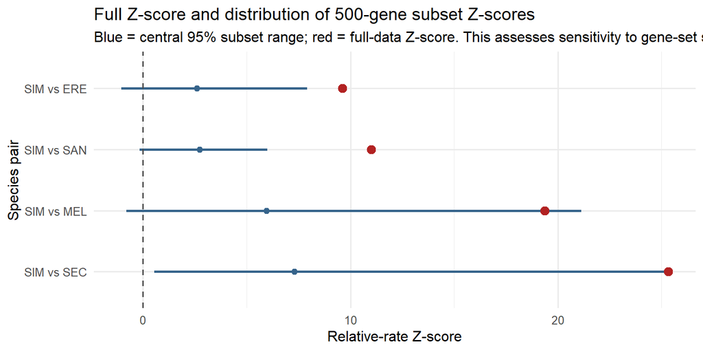

Full-data scores compared with empirical subset ranges.

```r
subset_interval_summary <- do.call(
  rbind,
  lapply(split(sampled_LA_finite, sampled_LA_finite$species2), function(df) {
    data.frame(
      species2 = as.character(df$species2[1]),
      comparison = paste(focus_taxon, "vs", as.character(df$species2[1])),
      subset_mean_z = mean(df$zscore),
      subset_lower_95 = unname(quantile(df$zscore, 0.025)),
      subset_upper_95 = unname(quantile(df$zscore, 0.975))
    )
  })
)
full_z_scores <- data.frame(
  species2 = as.character(tot_LA$species2),
  full_z_score = tot_LA$zscore
)
z_interval_summary <- merge(subset_interval_summary, full_z_scores, by = "species2", all.x = TRUE)
z_interval_summary$comparison <- factor(z_interval_summary$comparison, levels = paste(focus_taxon, "vs", species_order))
compact_interval_plot <- ggplot(z_interval_summary, aes(y = comparison)) +
  geom_segment(aes(x = subset_lower_95, xend = subset_upper_95, y = comparison, yend = comparison), color = "steelblue4", linewidth = 0.9) +
  geom_point(aes(x = subset_mean_z), color = "steelblue4", size = 2) +
  geom_point(aes(x = full_z_score), color = "firebrick", size = 3) +
  geom_vline(xintercept = 0, linetype = "dashed", color = "grey30") +
  theme_minimal(base_size = 12) +
  labs(title = "Full Z-score and distribution of 500-gene subset Z-scores", subtitle = "Blue = central 95% subset range; red = full-data Z-score. This assesses sensitivity to gene-set size, not independent validation.", x = "Relative-rate Z-score", y = "Species pair")
compact_interval_plot
```

```r
write.table(z_interval_summary, file = "treeexp_LA_SIM_500_subset_interval_summary.txt", quote = FALSE, col.names = TRUE, row.names = FALSE, sep = "\t")
ggsave("treeexp_LA_SIM_500_subset_vs_full_interval_plot.png", compact_interval_plot, width = 10, height = 4, dpi = 300)
```

# 10 11. Interpretation and Reproducibility

Positive Z-scores indicate faster transcriptome divergence for SIM relative to the named comparator under this relative-rate formulation. These scores describe lineage-wide expression-rate differences; they do not identify causal genes or establish altered brain function.